# Hospitalizations - EPI2 Scenarios

Pragati Prasad

2021-04-21

## Mean, Cumulative with 95% CI, and Averted per 100K

### Scenario HP13

Base Scenario: R0 of 1.7 and “2009-like” severity multiplied by 2 for all age groups except 65+, which remains the same as 2009

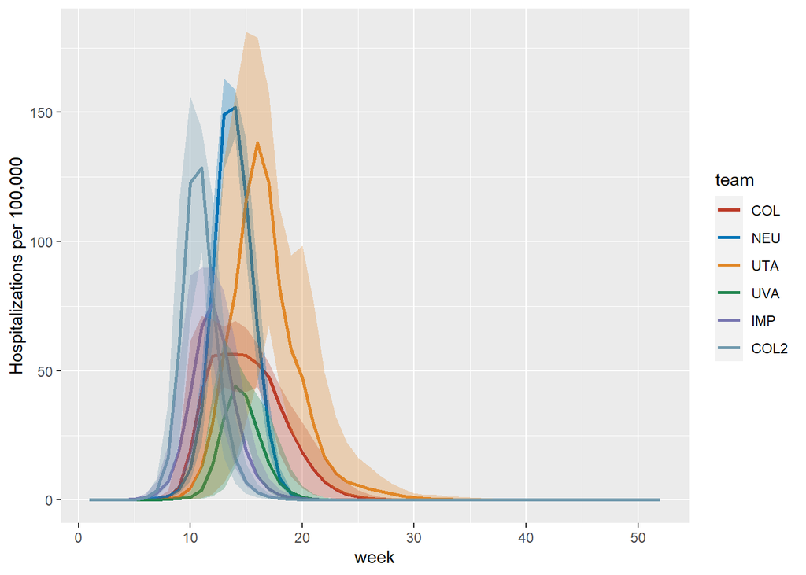

```r
library(ggsci)
library(reshape)
library(dplyr)
library(gridExtra)
library(ggplot2)
library(egg)
library(plyr)
library(tidyr)
library(knitr)
library(kableExtra)

path <- "../model-forecasts/"

team.folder <- c("Columbia/COL/EPI2/", "Northeastern/EPI2/", "UTAustin/", "UVirginia/", "Imperial/", "Columbia/COL2/EPI2/")
team.abbrev <- c("COL", "NEU", "UTA", "UVA", "IMP", "COL2")
file.types <-c("SymIllness", "Hosp", "Deaths", "AntiviralTX")
scn = "HP13_"
read_overall_mean <- function(scn){

  cols <- c("sm.mean", "sm.perc2p5", "sm.perc97p5")

  s <- read.csv(paste0(path,team.folder[1],scn,file.types[2],"_",team.abbrev[1],".csv"))
  hosp <- data.frame(c(s[which(s$Agegroup == "Overall" &
                                       s$Bin %in% cols),],
                             `team` = team.abbrev[1]))

  for(i in 2:6){

    if(i == 4){
      scn = gsub("HP", "HP_", scn)
    }
    if(i == 5){
      scn = gsub("_", "", scn)
    }
    if(i == 6){
      scn = paste0(scn, "_")
    }
    f = paste0(path,team.folder[i],scn,file.types[2],"_",team.abbrev[i],".csv")
    if(i == 5){
      f =  paste0(path,team.folder[i],scn,file.types[2],team.abbrev[i],".csv")
    }
    if(file.exists(f)){
      s <- read.csv(f)
      if(ncol(s) > 59){
        s <- s[-1]
      }
      if(i == 4){
        s <- s[which(s$Location == "US National"),]
      }
      hosp <- rbind.fill(hosp,
                               data.frame(c(s[which(s$Agegroup == "Overall" &
                                                      s$Bin %in% cols),],`team` = team.abbrev[i])))
    }

  }
  weeks <- paste0("Week",1:52)
  hosp$Cml[which(is.na(hosp$Cml))] <- hosp$cml[which(is.na(hosp$Cml))]
  cml <<- hosp[c("Cml", "team", "Bin")]

  long <- gather(hosp, week, illnesses, weeks, factor_key=TRUE)
  long$week <- as.integer(gsub("Week", "", long$week))

  cols <- c("Bin", "team", "week", "illnesses")
  long <- long[cols]
  long_wide <- spread(long, Bin, illnesses)

  return(long_wide)
}

long_HP13 <- read_overall_mean(scn = "HP13_")

ggplot(data = long_HP13, aes(x = week, y = sm.mean, group = team)) +
  geom_line(aes(color = team), lwd = 1.0) +
  geom_ribbon(aes(ymin = sm.perc2p5, ymax = sm.perc97p5, fill = team), alpha = 0.3,
              show.legend = FALSE)+
  ylab("Hospitalizations per 100,000") +
  scale_color_nejm() +
  scale_fill_nejm()
```

```r
table <- cml[which(cml$Bin == "sm.mean"),]
table <- table[,-3]

table$lower <-  cml$Cml[which(cml$Bin == "sm.perc2p5")]
table$upper <-  cml$Cml[which(cml$Bin == "sm.perc97p5")]
table$Team <- table$team
table$`Cum. Hospitalizations per 100K` <- table$Cml
table$`95% CI` <- paste0("(", round(table$lower, 2), ", ", round(table$upper, 2), ")")

rownames(table) <- NULL

knitr::kable(table[5:7], digits = 2, caption = "HP13, No Intervention", align=rep('c', 3)) %>%
  kable_styling(bootstrap_options = c("striped", "hover"))
```

HP13, No Intervention

| Team | Cum. Hospitalizations per 100K | 95% CI |
| --- | --- | --- |
| COL | 501.63 | (443.09, 559.75) |
| NEU | 662.12 | (661.28, 664.64) |
| UTA | 834.06 | (663.96, 950.01) |
| UVA | 187.81 | (162.95, 208.46) |
| IMP | 348.85 | (327.18, 373.55) |
| COL2 | 474.82 | (458.32, 492.04) |

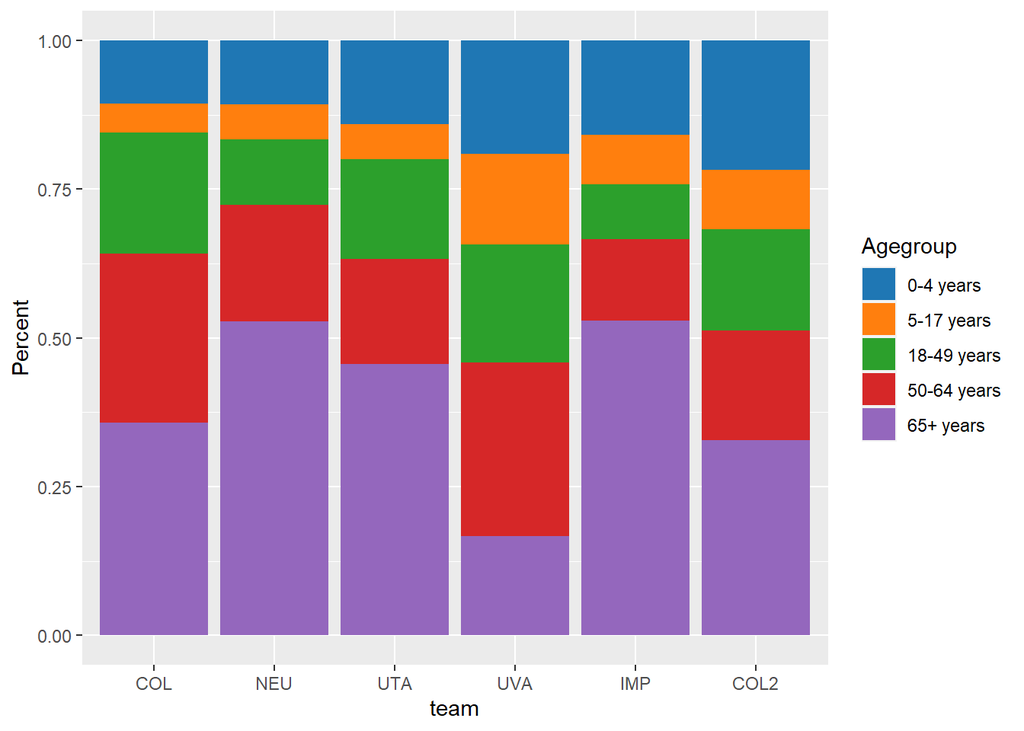

```r
table1 <- table


#Bar chart for age stratification
read_ages<- function(scn){

  cols <- c("sm.mean", "sm.perc2p5", "sm.perc97p5")

  s <- read.csv(paste0(path,team.folder[1],scn,file.types[2],"_",team.abbrev[1],".csv"))
  hosp <- data.frame(c(s[which(s$Agegroup != "Overall" &
                                       s$Bin %in% cols),],
                             `team` = team.abbrev[1]))

  for(i in 2:6){

    if(i == 4){
      scn = gsub("HP", "HP_", scn)
    }
    if(i == 5){
      scn = gsub("_", "", scn)
    }
    if(i == 6){
      scn = paste0(scn, "_")
    }
    f = paste0(path,team.folder[i],scn,file.types[2],"_",team.abbrev[i],".csv")
    if(i == 5){
      f =  paste0(path,team.folder[i],scn,file.types[2],team.abbrev[i],".csv")
    }
    if(file.exists(f)){
      s <- read.csv(f)
      if(ncol(s) > 58){
        s <- s[-1]
      }
      hosp <- rbind.fill(hosp,
                               data.frame(c(s[which(s$Agegroup != "Overall" &
                                                      s$Bin %in% cols),],`team` = team.abbrev[i])))
    }

  }
  weeks <- paste0("Week",1:52)
  hosp$Cml[which(is.na(hosp$Cml))] <- hosp$cml[which(is.na(hosp$Cml))]
  cml <- hosp[c("Cml", "team", "Bin", "Agegroup")]
  cml$Agegroup <- sub("yr", "years", cml$Agegroup)
  cml$Agegroup <- factor(x = cml$Agegroup, levels = c("0-4 years", "5-17 years", "18-49 years", "50-64 years", "65+ years"))

  return(cml)
}

ages_1 <- read_ages(scn = "HP13_")
ggplot(ages_1, aes(fill=Agegroup, y=Cml, x=team)) +
  geom_bar(position="fill", stat="identity") +
  ylab("Percent")+
  scale_fill_d3()
```

```r
scenario = "HP13_"
averted_age <- data.frame(scenario = scenario,
                          team = ages_1$team[which(ages_1$Bin == "sm.mean")],
                          agegroup = ages_1$Agegroup[which(ages_1$Bin == "sm.mean")],
                          cml = ages_1$Cml[which(ages_1$Bin == "sm.mean")],
                          lower = ages_1$Cml[which(ages_1$Bin == "sm.perc2p5")],
                          upper = ages_1$Cml[which(ages_1$Bin == "sm.perc97p5")])
write.csv(averted_age, "Hospitalizations_EPI2_HP13.csv")
```

### HP14

VX1

“Early”: Vaccine available 100 days after September 1

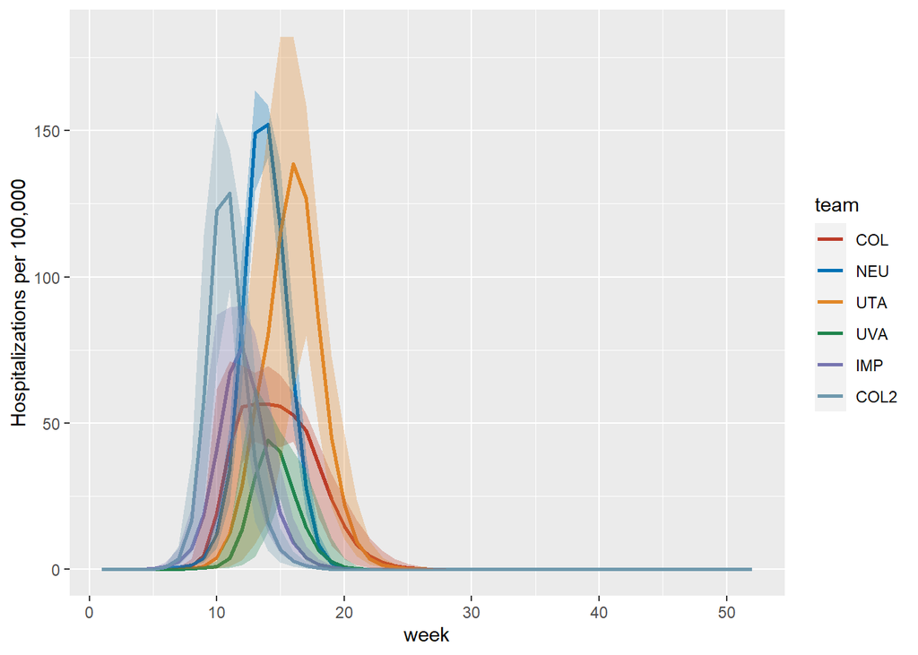

```r
scenario <- "HP14_"

long <- read_overall_mean(scn = scenario)

ggplot(data = long, aes(x = week, y = sm.mean, group = team)) +
  geom_line(aes(color = team), lwd = 1.0) +
  geom_ribbon(aes(ymin = sm.perc2p5, ymax = sm.perc97p5, fill = team), alpha = 0.3,
              show.legend = FALSE)+
  ylab("Hospitalizations per 100,000") +
  scale_color_nejm() +
  scale_fill_nejm()
```

```r
table <- cml[which(cml$Bin == "sm.mean"),]
table <- table[,-3]

table$lower <-  cml$Cml[which(cml$Bin == "sm.perc2p5")]
table$upper <-  cml$Cml[which(cml$Bin == "sm.perc97p5")]
table$Team <- table$team
table$`Cum. Hospitalizations per 100K` <- table$Cml
table$`95% CI` <- paste0("(", round(table$lower, 2), ", ", round(table$upper, 2), ")")

table$`Averted Hospitalizations per 100K (HP13)` <- ifelse(table$Team %in% table1$Team, table1$`Cum. Hospitalizations per 100K` - table$`Cum. Hospitalizations per 100K`, NA)
table$`% Reduction in Burden (HP13)` <- ifelse(table$Team %in% table1$Team, 100 * (table1$`Cum. Hospitalizations per 100K` - table$`Cum. Hospitalizations per 100K`) / table1$`Cum. Hospitalizations per 100K`, NA)

rownames(table) <- NULL

knitr::kable(table[5:9], digits = 2, caption = "HP14: Compared to HP13", align=rep('c', 4)) %>%
  kable_styling(bootstrap_options = c("striped", "hover"))
```

HP14: Compared to HP13

| Team | Cum. Hospitalizations per 100K | 95% CI | Averted Hospitalizations per 100K (HP13) | % Reduction in Burden (HP13) |
| --- | --- | --- | --- | --- |
| COL | 484.49 | (409.75, 553.57) | 17.14 | 3.42 |
| NEU | 661.83 | (661.04, 664.11) | 0.29 | 0.04 |
| UTA | 730.21 | (454.95, 903.62) | 103.85 | 12.45 |
| UVA | 186.83 | (158.03, 208.4) | 0.99 | 0.52 |
| IMP | 347.84 | (325.57, 372.97) | 1.01 | 0.29 |
| COL2 | 474.70 | (458.04, 491.84) | 0.12 | 0.03 |

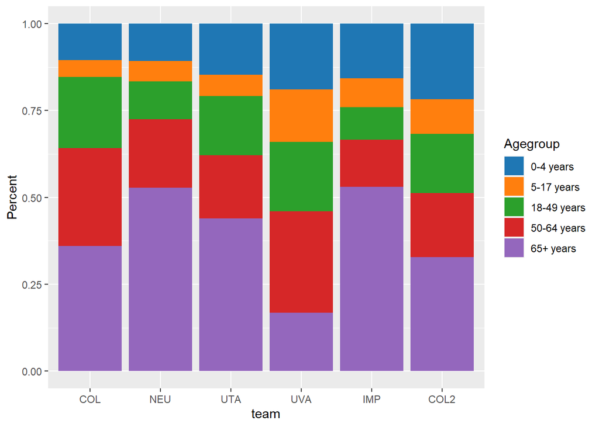

```r
#Bar chart for ages
ages <- read_ages(scn = scenario)
ggplot(ages, aes(fill=Agegroup, y=Cml, x=team)) +
  geom_bar(position="fill", stat="identity") +
  ylab("Percent")+
  scale_fill_d3()
```

```r
averted <- data.frame(scenario = rep(scenario, nrow(table)),
                                     team = table$Team,
                                     reduction = table$`% Reduction in Burden (HP13)`)

averted_age <- data.frame(scenario = scenario,
                          team = ages$team[which(ages$Bin == "sm.mean")],
                          agegroup = ages$Agegroup[which(ages$Bin == "sm.mean")],
                          reduction = 100*(ages_1$Cml[which(ages_1$Bin == "sm.mean")] -
                                       ages$Cml[which(ages$Bin == "sm.mean")]) /
                            ages_1$Cml[which(ages_1$Bin == "sm.mean")])
```

### HP15

VX2

“Normal”: Vaccine available 150 days after September 1

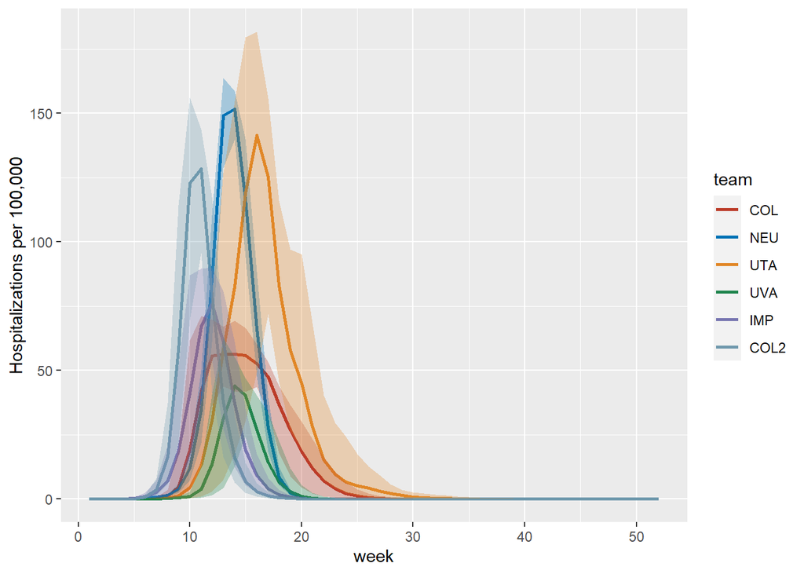

```r
scenario <- "HP15_"

long <- read_overall_mean(scn = scenario)

ggplot(data = long, aes(x = week, y = sm.mean, group = team)) +
  geom_line(aes(color = team), lwd = 1.0) +
  geom_ribbon(aes(ymin = sm.perc2p5, ymax = sm.perc97p5, fill = team), alpha = 0.3,
              show.legend = FALSE)+
  ylab("Hospitalizations per 100,000") +
  scale_color_nejm() +
  scale_fill_nejm()
```

```r
table <- cml[which(cml$Bin == "sm.mean"),]
table <- table[,-3]

table$lower <-  cml$Cml[which(cml$Bin == "sm.perc2p5")]
table$upper <-  cml$Cml[which(cml$Bin == "sm.perc97p5")]
table$Team <- table$team
table$`Cum. Hospitalizations per 100K` <- table$Cml
table$`95% CI` <- paste0("(", round(table$lower, 2), ", ", round(table$upper, 2), ")")

table$`Averted Hospitalizations per 100K (HP13)` <- ifelse(table$Team %in% table1$Team, table1$`Cum. Hospitalizations per 100K` - table$`Cum. Hospitalizations per 100K`, NA)
table$`% Reduction in Burden (HP13)` <- ifelse(table$Team %in% table1$Team, 100 * (table1$`Cum. Hospitalizations per 100K` - table$`Cum. Hospitalizations per 100K`) / table1$`Cum. Hospitalizations per 100K`, NA)

rownames(table) <- NULL

knitr::kable(table[5:9], digits = 2, caption = "HP15: Compared to HP13", align=rep('c', 4)) %>%
  kable_styling(bootstrap_options = c("striped", "hover"))
```

HP15: Compared to HP13

| Team | Cum. Hospitalizations per 100K | 95% CI | Averted Hospitalizations per 100K (HP13) | % Reduction in Burden (HP13) |
| --- | --- | --- | --- | --- |
| COL | 501.63 | (443.09, 559.75) | 0.00 | 0.00 |
| NEU | 662.08 | (661.27, 664.6) | 0.03 | 0.01 |
| UTA | 840.51 | (682.72, 948.38) | -6.45 | -0.77 |
| UVA | 187.81 | (162.94, 208.46) | 0.00 | 0.00 |
| IMP | 347.84 | (325.57, 372.97) | 1.01 | 0.29 |
| COL2 | 474.82 | (458.32, 492.04) | 0.00 | 0.00 |

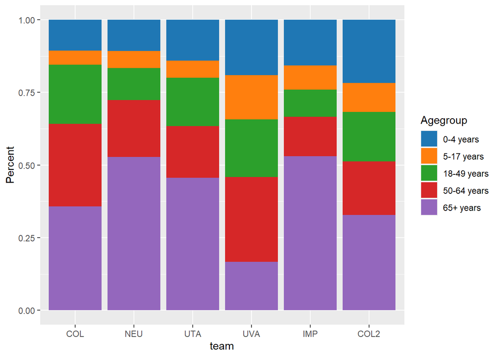

```r
#Bar chart for ages
ages <- read_ages(scn = scenario)
ggplot(ages, aes(fill=Agegroup, y=Cml, x=team)) +
  geom_bar(position="fill", stat="identity") +
  ylab("Percent")+
  scale_fill_d3()
```

```r
averted <- rbind(averted, data.frame(scenario = rep(scenario, nrow(table)),
                                     team = table$Team,
                                     reduction = table$`% Reduction in Burden (HP13)`))

averted_age <- rbind(averted_age,
                     data.frame(scenario = scenario,
                          team = ages$team[which(ages$Bin == "sm.mean")],
                          agegroup = ages$Agegroup[which(ages$Bin == "sm.mean")],
                          reduction = 100*(ages_1$Cml[which(ages_1$Bin == "sm.mean")] -
                                       ages$Cml[which(ages$Bin == "sm.mean")]) /
                            ages_1$Cml[which(ages_1$Bin == "sm.mean")]))
```

### HP16

SC1

Weekly Symptomatic Prevalence > 1% trigger, early (VX1) vaccine availability reopening

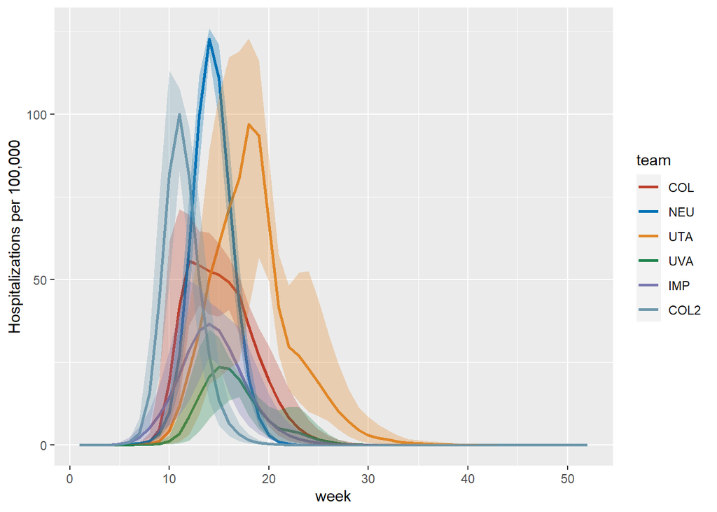

```r
scenario <- "HP16_"

long <- read_overall_mean(scn = scenario)

ggplot(data = long, aes(x = week, y = sm.mean, group = team, color = team)) +
  geom_line(aes(color = team), lwd = 1.0) +
  geom_ribbon(aes(ymin = sm.perc2p5, ymax = sm.perc97p5, fill = team),
              alpha = 0.3,
              linetype=0,
              show.legend = FALSE)+
  ylab("Hospitalizations per 100,000") +
  scale_color_nejm() +
  scale_fill_nejm()
```

```r
table <- cml[which(cml$Bin == "sm.mean"),]
table <- table[,-3]

table$lower <-  cml$Cml[which(cml$Bin == "sm.perc2p5")]
table$upper <-  cml$Cml[which(cml$Bin == "sm.perc97p5")]
table$Team <- table$team
table$`Cum. Hospitalizations per 100K` <- table$Cml
table$`95% CI` <- paste0("(", round(table$lower, 2), ", ", round(table$upper, 2), ")")

table$`Averted Hospitalizations per 100K (HP13)` <- ifelse(table$Team %in% table1$Team, table1$`Cum. Hospitalizations per 100K` - table$`Cum. Hospitalizations per 100K`, NA)
table$`% Reduction in Burden (HP13)` <- ifelse(table$Team %in% table1$Team, 100 * (table1$`Cum. Hospitalizations per 100K` - table$`Cum. Hospitalizations per 100K`) / table1$`Cum. Hospitalizations per 100K`, NA)

rownames(table) <- NULL

knitr::kable(table[5:9], digits = 2, caption = "HP16: Compared to HP13", align=rep('c', 4)) %>%
  kable_styling(bootstrap_options = c("striped", "hover"))
```

HP16: Compared to HP13

| Team | Cum. Hospitalizations per 100K | 95% CI | Averted Hospitalizations per 100K (HP13) | % Reduction in Burden (HP13) |
| --- | --- | --- | --- | --- |
| COL | 491.48 | (435.35, 549.63) | 10.15 | 2.02 |
| NEU | 586.85 | (586.24, 588.65) | 75.27 | 11.37 |
| UTA | 781.47 | (620.07, 897.49) | 52.59 | 6.31 |
| UVA | 169.82 | (149.32, 191.29) | 18.00 | 9.58 |
| IMP | 288.62 | (266.28, 311.92) | 60.23 | 17.27 |
| COL2 | 430.79 | (413.42, 449.67) | 44.03 | 9.27 |

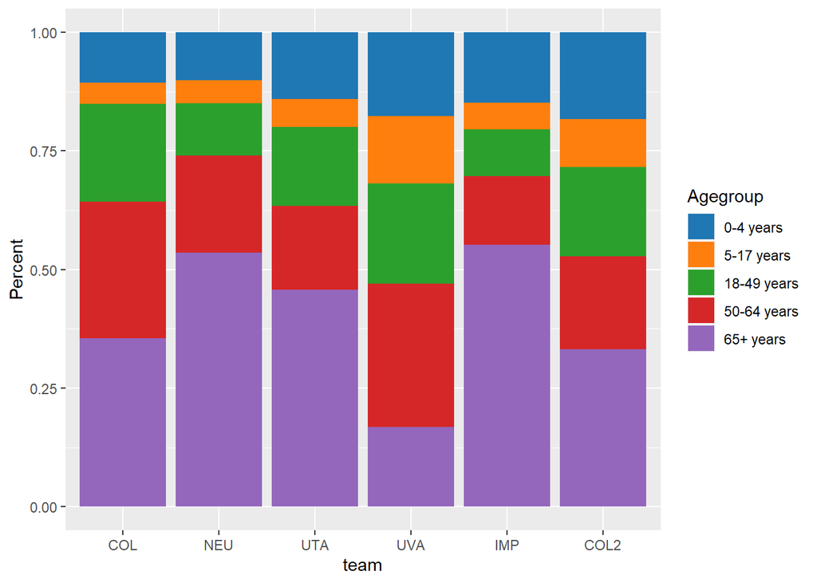

```r
#Bar chart for ages
ages <- read_ages(scn = scenario)
ggplot(ages, aes(fill=Agegroup, y=Cml, x=team)) +
  geom_bar(position="fill", stat="identity") +
  ylab("Percent")+
  scale_fill_d3()
```

```r
averted <- rbind(averted, data.frame(scenario = rep(scenario, nrow(table)),
                                     team = table$Team,
                                     reduction = table$`% Reduction in Burden (HP13)`))

averted_age <- rbind(averted_age,
                     data.frame(scenario = scenario,
                          team = ages$team[which(ages$Bin == "sm.mean")],
                          agegroup = ages$Agegroup[which(ages$Bin == "sm.mean")],
                          reduction = 100*(ages_1$Cml[which(ages_1$Bin == "sm.mean")] -
                                       ages$Cml[which(ages$Bin == "sm.mean")]) /
                            ages_1$Cml[which(ages_1$Bin == "sm.mean")]))
```

### HP17

SC2

Close on October 28, early (VX1) vaccine availability reopening

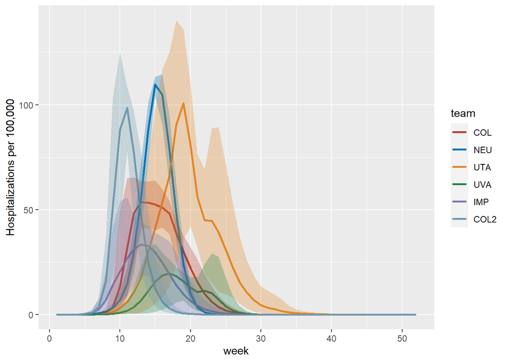

```r
scenario <- "HP17_"

long <- read_overall_mean(scn = scenario)

ggplot(data = long, aes(x = week, y = sm.mean, group = team)) +
  geom_line(aes(color = team), lwd = 1.0) +
  geom_ribbon(aes(ymin = sm.perc2p5, ymax = sm.perc97p5, fill = team), alpha = 0.3,
              show.legend = FALSE)+
  ylab("Hospitalizations per 100,000") +
  scale_color_nejm() +
  scale_fill_nejm()
```

```r
table <- cml[which(cml$Bin == "sm.mean"),]
table <- table[,-3]

table$lower <-  cml$Cml[which(cml$Bin == "sm.perc2p5")]
table$upper <-  cml$Cml[which(cml$Bin == "sm.perc97p5")]
table$Team <- table$team
table$`Cum. Hospitalizations per 100K` <- table$Cml
table$`95% CI` <- paste0("(", round(table$lower, 2), ", ", round(table$upper, 2), ")")

table$`Averted Hospitalizations per 100K (HP13)` <- ifelse(table$Team %in% table1$Team, table1$`Cum. Hospitalizations per 100K` - table$`Cum. Hospitalizations per 100K`, NA)
table$`% Reduction in Burden (HP13)` <- ifelse(table$Team %in% table1$Team, 100 * (table1$`Cum. Hospitalizations per 100K` - table$`Cum. Hospitalizations per 100K`) / table1$`Cum. Hospitalizations per 100K`, NA)

rownames(table) <- NULL

knitr::kable(table[5:9], digits = 2, caption = "HP17: Compared to HP13", align=rep('c', 4)) %>%
  kable_styling(bootstrap_options = c("striped", "hover"))
```

HP17: Compared to HP13

| Team | Cum. Hospitalizations per 100K | 95% CI | Averted Hospitalizations per 100K (HP13) | % Reduction in Burden (HP13) |
| --- | --- | --- | --- | --- |
| COL | 488.35 | (432.7, 546) | 13.28 | 2.65 |
| NEU | 582.36 | (581.97, 583.41) | 79.75 | 12.05 |
| UTA | 789.82 | (657.61, 915.3) | 44.25 | 5.30 |
| UVA | 174.62 | (159.65, 191.21) | 13.20 | 7.03 |
| IMP | 286.46 | (269.23, 311.54) | 62.40 | 17.89 |
| COL2 | 431.99 | (414.06, 451.5) | 42.83 | 9.02 |

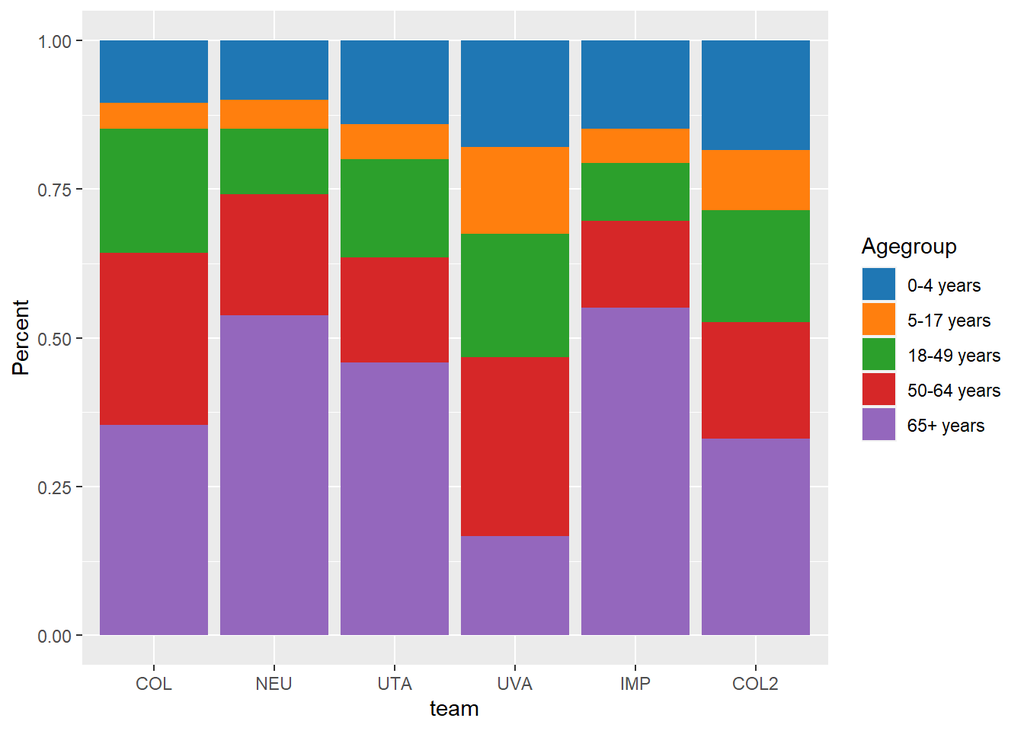

```r
#Bar chart for ages
ages <- read_ages(scn = scenario)
ggplot(ages, aes(fill=Agegroup, y=Cml, x=team)) +
  geom_bar(position="fill", stat="identity") +
  ylab("Percent")+
  scale_fill_d3()
```

```r
averted <- rbind(averted, data.frame(scenario = rep(scenario, nrow(table)),
                                     team = table$Team,
                                     reduction = table$`% Reduction in Burden (HP13)`))

averted_age <- rbind(averted_age,
                     data.frame(scenario = scenario,
                          team = ages$team[which(ages$Bin == "sm.mean")],
                          agegroup = ages$Agegroup[which(ages$Bin == "sm.mean")],
                          reduction = 100*(ages_1$Cml[which(ages_1$Bin == "sm.mean")] -
                                       ages$Cml[which(ages$Bin == "sm.mean")]) /
                            ages_1$Cml[which(ages_1$Bin == "sm.mean")]))
```

### HP18

SC3

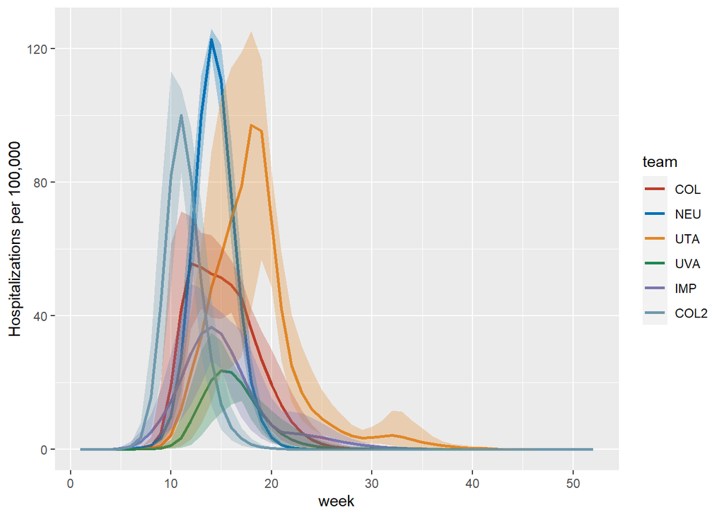

```r
scenario <- "HP18_"

long <- read_overall_mean(scn = scenario)

ggplot(data = long, aes(x = week, y = sm.mean, group = team)) +
  geom_line(aes(color = team), lwd = 1.0) +
  geom_ribbon(aes(ymin = sm.perc2p5, ymax = sm.perc97p5, fill = team), alpha = 0.3,
              show.legend = FALSE)+
  ylab("Hospitalizations per 100,000") +
  scale_color_nejm() +
  scale_fill_nejm()
```

```r
table <- cml[which(cml$Bin == "sm.mean"),]
table <- table[,-3]

table$lower <-  cml$Cml[which(cml$Bin == "sm.perc2p5")]
table$upper <-  cml$Cml[which(cml$Bin == "sm.perc97p5")]
table$Team <- table$team
table$`Cum. Hospitalizations per 100K` <- table$Cml
table$`95% CI` <- paste0("(", round(table$lower, 2), ", ", round(table$upper, 2), ")")

table$`Averted Hospitalizations per 100K (HP13)` <- ifelse(table$Team %in% table1$Team, table1$`Cum. Hospitalizations per 100K` - table$`Cum. Hospitalizations per 100K`, NA)
table$`% Reduction in Burden (HP13)` <- ifelse(table$Team %in% table1$Team, 100 * (table1$`Cum. Hospitalizations per 100K` - table$`Cum. Hospitalizations per 100K`) / table1$`Cum. Hospitalizations per 100K`, NA)

rownames(table) <- NULL

knitr::kable(table[5:9], digits = 2, caption = "HP18: Compared to HP13", align=rep('c', 4)) %>%
  kable_styling(bootstrap_options = c("striped", "hover"))
```

HP18: Compared to HP13

| Team | Cum. Hospitalizations per 100K | 95% CI | Averted Hospitalizations per 100K (HP13) | % Reduction in Burden (HP13) |
| --- | --- | --- | --- | --- |
| COL | 490.95 | (434.23, 549.44) | 10.68 | 2.13 |
| NEU | 588.80 | (587.94, 591.28) | 73.32 | 11.07 |
| UTA | 740.48 | (518.73, 890.64) | 93.58 | 11.22 |
| UVA | 163.87 | (134.7, 190.2) | 23.94 | 12.75 |
| IMP | 309.74 | (295.2, 330.59) | 39.11 | 11.21 |
| COL2 | 430.60 | (412.92, 449.47) | 44.23 | 9.31 |

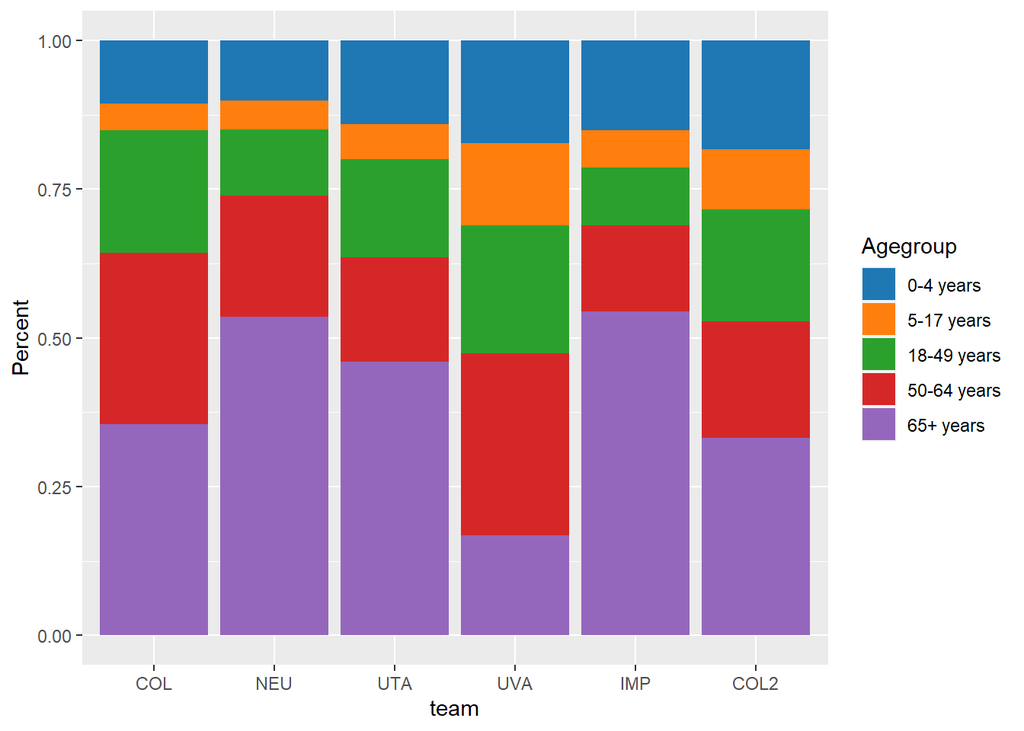

```r
#Bar chart for ages
ages <- read_ages(scn = scenario)
ggplot(ages, aes(fill=Agegroup, y=Cml, x=team)) +
  geom_bar(position="fill", stat="identity") +
  ylab("Percent")+
  scale_fill_d3()
```

```r
averted <- rbind(averted, data.frame(scenario = rep(scenario, nrow(table)),
                                     team = table$Team,
                                     reduction = table$`% Reduction in Burden (HP13)`))

averted_age <- rbind(averted_age,
                     data.frame(scenario = scenario,
                          team = ages$team[which(ages$Bin == "sm.mean")],
                          agegroup = ages$Agegroup[which(ages$Bin == "sm.mean")],
                          reduction = 100*(ages_1$Cml[which(ages_1$Bin == "sm.mean")] -
                                       ages$Cml[which(ages$Bin == "sm.mean")]) /
                            ages_1$Cml[which(ages_1$Bin == "sm.mean")]))
```

### HP19

SC4

Close on October 28, normal (VX2) vaccine availability reopening

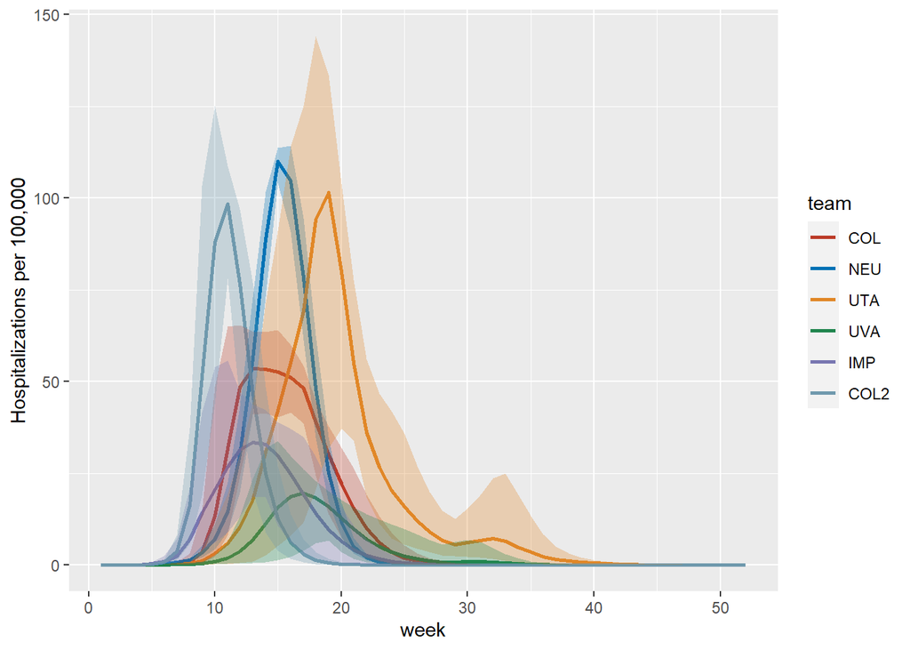

```r
scenario <- "HP19_"

long <- read_overall_mean(scn = scenario)

ggplot(data = long, aes(x = week, y = sm.mean, group = team)) +
  geom_line(aes(color = team), lwd = 1.0) +
  geom_ribbon(aes(ymin = sm.perc2p5, ymax = sm.perc97p5, fill = team), alpha = 0.3,
              show.legend = FALSE)+
  ylab("Hospitalizations per 100,000") +
  scale_color_nejm() +
  scale_fill_nejm()
```

```r
table <- cml[which(cml$Bin == "sm.mean"),]
table <- table[,-3]

table$lower <-  cml$Cml[which(cml$Bin == "sm.perc2p5")]
table$upper <-  cml$Cml[which(cml$Bin == "sm.perc97p5")]
table$Team <- table$team
table$`Cum. Hospitalizations per 100K` <- table$Cml
table$`95% CI` <- paste0("(", round(table$lower, 2), ", ", round(table$upper, 2), ")")

table$`Averted Hospitalizations per 100K (HP13)` <- ifelse(table$Team %in% table1$Team, table1$`Cum. Hospitalizations per 100K` - table$`Cum. Hospitalizations per 100K`, NA)
table$`% Reduction in Burden (HP13)` <- ifelse(table$Team %in% table1$Team, 100 * (table1$`Cum. Hospitalizations per 100K` - table$`Cum. Hospitalizations per 100K`) / table1$`Cum. Hospitalizations per 100K`, NA)

rownames(table) <- NULL

knitr::kable(table[5:9], digits = 2, caption = "HP19: Compared to HP13", align=rep('c', 4)) %>%
  kable_styling(bootstrap_options = c("striped", "hover"))
```

HP19: Compared to HP13

| Team | Cum. Hospitalizations per 100K | 95% CI | Averted Hospitalizations per 100K (HP13) | % Reduction in Burden (HP13) |
| --- | --- | --- | --- | --- |
| COL | 487.70 | (431.37, 545.86) | 13.93 | 2.78 |
| NEU | 589.18 | (588.24, 591.85) | 72.93 | 11.02 |
| UTA | 742.26 | (516.91, 899.46) | 91.80 | 11.01 |
| UVA | 164.41 | (143.49, 189.64) | 23.40 | 12.46 |
| IMP | 286.46 | (269.23, 311.54) | 62.40 | 17.89 |
| COL2 | 431.81 | (413.87, 451.46) | 43.01 | 9.06 |

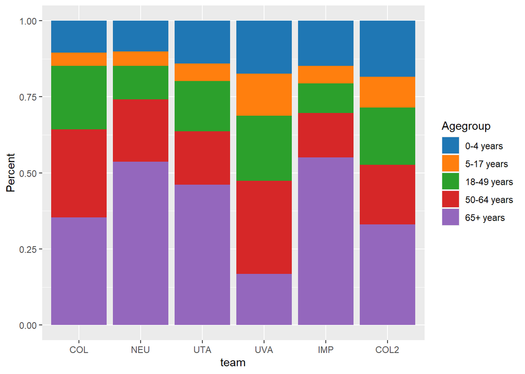

```r
#Bar chart for ages
ages <- read_ages(scn = scenario)
ggplot(ages, aes(fill=Agegroup, y=Cml, x=team)) +
  geom_bar(position="fill", stat="identity") +
  ylab("Percent")+
  scale_fill_d3()
```

```r
averted <- rbind(averted, data.frame(scenario = rep(scenario, nrow(table)),
                                     team = table$Team,
                                     reduction = table$`% Reduction in Burden (HP13)`))

averted_age <- rbind(averted_age,
                     data.frame(scenario = scenario,
                          team = ages$team[which(ages$Bin == "sm.mean")],
                          agegroup = ages$Agegroup[which(ages$Bin == "sm.mean")],
                          reduction = 100*(ages_1$Cml[which(ages_1$Bin == "sm.mean")] -
                                       ages$Cml[which(ages$Bin == "sm.mean")]) /
                            ages_1$Cml[which(ages_1$Bin == "sm.mean")]))
```

### HP20

AV

Antivirals

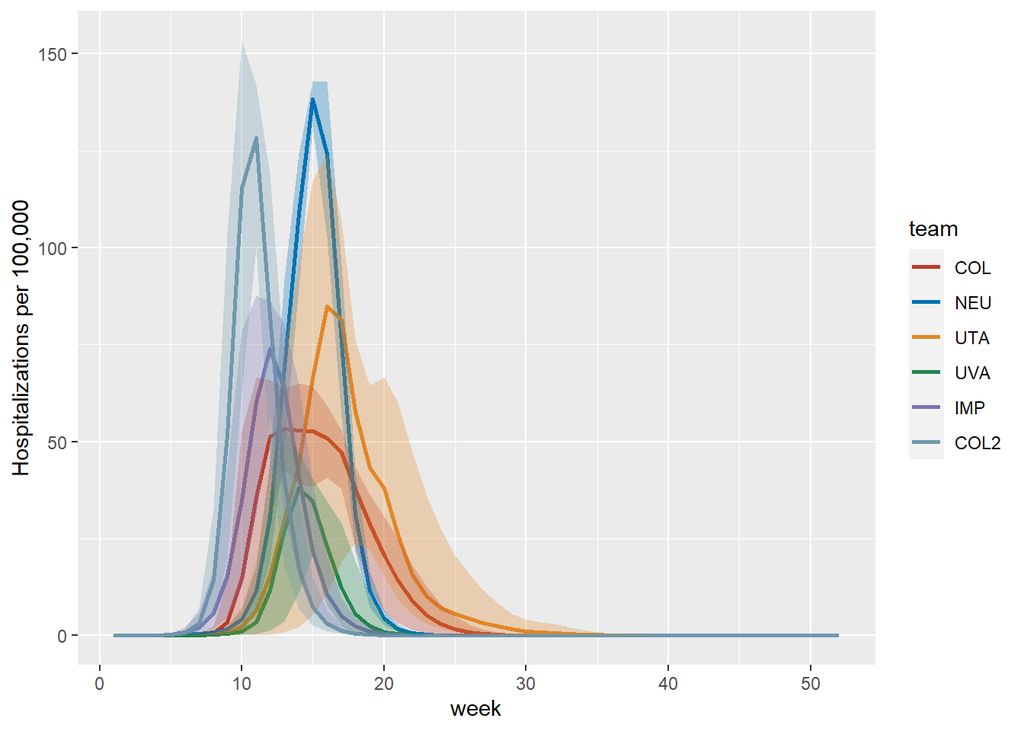

```r
scenario <- "HP20_"

long <- read_overall_mean(scn = scenario)

ggplot(data = long, aes(x = week, y = sm.mean, group = team)) +
  geom_line(aes(color = team), lwd = 1.0) +
  geom_ribbon(aes(ymin = sm.perc2p5, ymax = sm.perc97p5, fill = team), alpha = 0.3,
              show.legend = FALSE)+
  ylab("Hospitalizations per 100,000") +
  scale_color_nejm() +
  scale_fill_nejm()
```

```r
table <- cml[which(cml$Bin == "sm.mean"),]
table <- table[,-3]

table$lower <-  cml$Cml[which(cml$Bin == "sm.perc2p5")]
table$upper <-  cml$Cml[which(cml$Bin == "sm.perc97p5")]
table$Team <- table$team
table$`Cum. Hospitalizations per 100K` <- table$Cml
table$`95% CI` <- paste0("(", round(table$lower, 2), ", ", round(table$upper, 2), ")")

table$`Averted Hospitalizations per 100K (HP13)` <- ifelse(table$Team %in% table1$Team, table1$`Cum. Hospitalizations per 100K` - table$`Cum. Hospitalizations per 100K`, NA)
table$`% Reduction in Burden (HP13)` <- ifelse(table$Team %in% table1$Team, 100 * (table1$`Cum. Hospitalizations per 100K` - table$`Cum. Hospitalizations per 100K`) / table1$`Cum. Hospitalizations per 100K`, NA)

rownames(table) <- NULL

knitr::kable(table[5:9], digits = 2, caption = "HP20: Compared to HP13", align=rep('c', 4)) %>%
  kable_styling(bootstrap_options = c("striped", "hover"))
```

HP20: Compared to HP13

| Team | Cum. Hospitalizations per 100K | 95% CI | Averted Hospitalizations per 100K (HP13) | % Reduction in Burden (HP13) |
| --- | --- | --- | --- | --- |
| COL | 484.80 | (428.21, 543.08) | 16.83 | 3.35 |
| NEU | 614.82 | (614.43, 615.95) | 47.30 | 7.14 |
| UTA | 550.25 | (390.9, 641.86) | 283.81 | 34.03 |
| UVA | 161.30 | (140.02, 178.96) | 26.52 | 14.12 |
| IMP | 340.31 | (319.23, 364.52) | 8.54 | 2.45 |
| COL2 | 465.79 | (449.09, 483.34) | 9.04 | 1.90 |

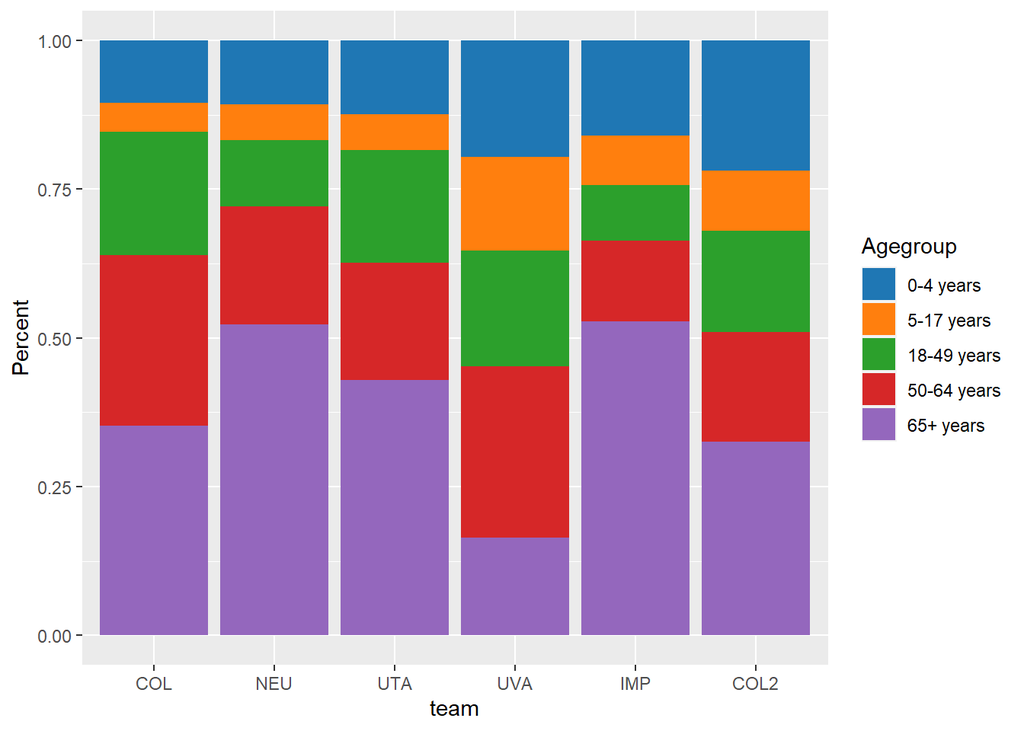

```r
#Bar chart for ages
ages <- read_ages(scn = scenario)
ggplot(ages, aes(fill=Agegroup, y=Cml, x=team)) +
  geom_bar(position="fill", stat="identity") +
  ylab("Percent")+
  scale_fill_d3()
```

```r
averted <- rbind(averted, data.frame(scenario = rep(scenario, nrow(table)),
                                     team = table$Team,
                                     reduction = table$`% Reduction in Burden (HP13)`))

averted_age <- rbind(averted_age,
                     data.frame(scenario = scenario,
                          team = ages$team[which(ages$Bin == "sm.mean")],
                          agegroup = ages$Agegroup[which(ages$Bin == "sm.mean")],
                          reduction = 100*(ages_1$Cml[which(ages_1$Bin == "sm.mean")] -
                                       ages$Cml[which(ages$Bin == "sm.mean")]) /
                            ages_1$Cml[which(ages_1$Bin == "sm.mean")]))
```

### HP21

VX1 & SC1 & AV

- “Early”: Vaccine available 100 days after September 1
- Weekly Symptomatic Prevalence > 1% trigger, early (VX1) vaccine availability reopening
- Antivirals

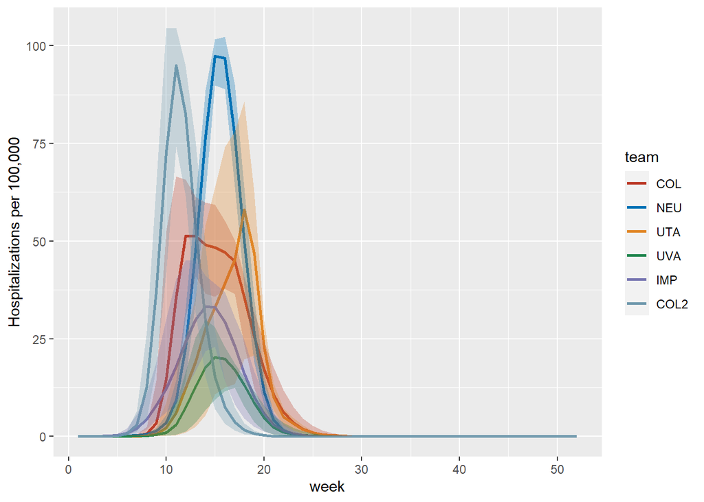

```r
scenario <- "HP21_"

long <- read_overall_mean(scn = scenario)

ggplot(data = long, aes(x = week, y = sm.mean, group = team)) +
  geom_line(aes(color = team), lwd = 1.0) +
  geom_ribbon(aes(ymin = sm.perc2p5, ymax = sm.perc97p5, fill = team), alpha = 0.3,
              show.legend = FALSE)+
  ylab("Hospitalizations per 100,000") +
  scale_color_nejm() +
  scale_fill_nejm()
```

```r
table <- cml[which(cml$Bin == "sm.mean"),]
table <- table[,-3]

table$lower <-  cml$Cml[which(cml$Bin == "sm.perc2p5")]
table$upper <-  cml$Cml[which(cml$Bin == "sm.perc97p5")]
table$Team <- table$team
table$`Cum. Hospitalizations per 100K` <- table$Cml
table$`95% CI` <- paste0("(", round(table$lower, 2), ", ", round(table$upper, 2), ")")

table$`Averted Hospitalizations per 100K (HP13)` <- ifelse(table$Team %in% table1$Team, table1$`Cum. Hospitalizations per 100K` - table$`Cum. Hospitalizations per 100K`, NA)
table$`% Reduction in Burden (HP13)` <- ifelse(table$Team %in% table1$Team, 100 * (table1$`Cum. Hospitalizations per 100K` - table$`Cum. Hospitalizations per 100K`) / table1$`Cum. Hospitalizations per 100K`, NA)

rownames(table) <- NULL

knitr::kable(table[5:9], digits = 2, caption = "HP21: Compared to HP13", align=rep('c', 4)) %>%
  kable_styling(bootstrap_options = c("striped", "hover"))
```

HP21: Compared to HP13

| Team | Cum. Hospitalizations per 100K | 95% CI | Averted Hospitalizations per 100K (HP13) | % Reduction in Burden (HP13) |
| --- | --- | --- | --- | --- |
| COL | 449.22 | (377.88, 522.16) | 52.41 | 10.45 |
| NEU | 527.70 | (527.26, 529.07) | 134.41 | 20.30 |
| UTA | 335.74 | (130.45, 506.51) | 498.32 | 59.75 |
| UVA | 131.14 | (91.61, 160.78) | 56.67 | 30.17 |
| IMP | 256.36 | (222.12, 290.27) | 92.50 | 26.51 |
| COL2 | 416.80 | (398.83, 436.32) | 58.03 | 12.22 |

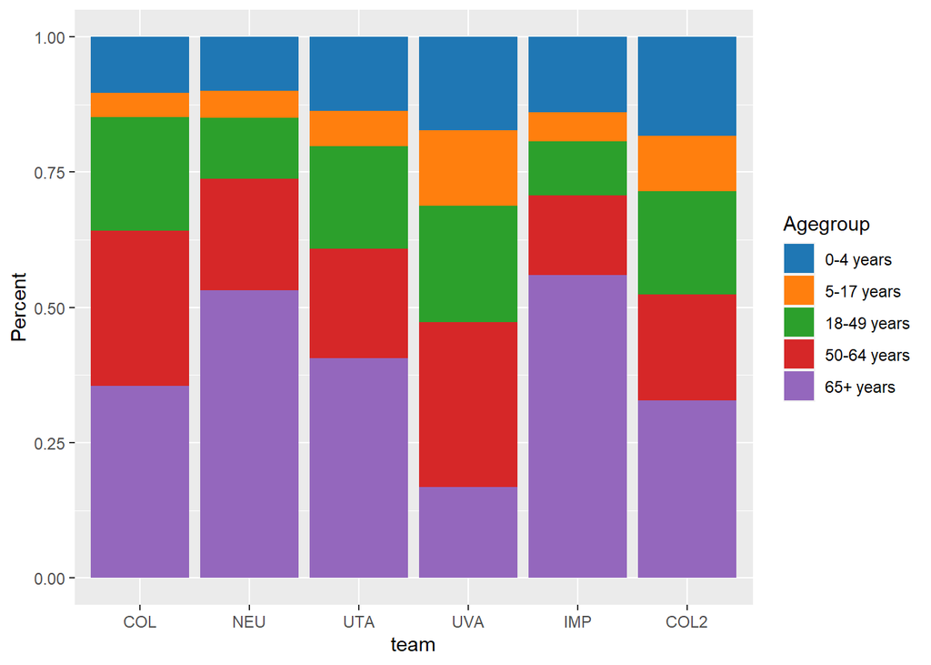

```r
#Bar chart for ages
ages <- read_ages(scn = scenario)
ggplot(ages, aes(fill=Agegroup, y=Cml, x=team)) +
  geom_bar(position="fill", stat="identity") +
  ylab("Percent")+
  scale_fill_d3()
```

```r
averted <- rbind(averted, data.frame(scenario = rep(scenario, nrow(table)),
                                     team = table$Team,
                                     reduction = table$`% Reduction in Burden (HP13)`))

averted_age <- rbind(averted_age,
                     data.frame(scenario = scenario,
                          team = ages$team[which(ages$Bin == "sm.mean")],
                          agegroup = ages$Agegroup[which(ages$Bin == "sm.mean")],
                          reduction = 100*(ages_1$Cml[which(ages_1$Bin == "sm.mean")] -
                                       ages$Cml[which(ages$Bin == "sm.mean")]) /
                            ages_1$Cml[which(ages_1$Bin == "sm.mean")]))
```

### HP22

VX1 & SC2 & AV

- “Early”: Vaccine available 100 days after September 1
- Close on October 28, early (VX1) vaccine availability reopening
- Antivirals

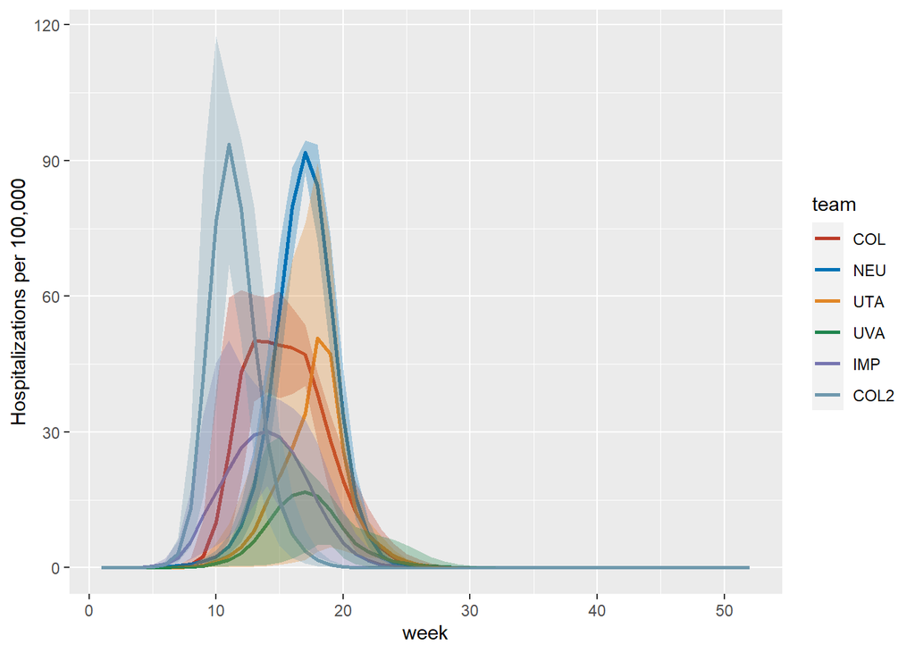

```r
scenario <- "HP22_"

long <- read_overall_mean(scn = scenario)

ggplot(data = long, aes(x = week, y = sm.mean, group = team)) +
  geom_line(aes(color = team), lwd = 1.0) +
  geom_ribbon(aes(ymin = sm.perc2p5, ymax = sm.perc97p5, fill = team), alpha = 0.3,
              show.legend = FALSE)+
  ylab("Hospitalizations per 100,000") +
  scale_color_nejm() +
  scale_fill_nejm()
```

```r
table <- cml[which(cml$Bin == "sm.mean"),]
table <- table[,-3]

table$lower <-  cml$Cml[which(cml$Bin == "sm.perc2p5")]
table$upper <-  cml$Cml[which(cml$Bin == "sm.perc97p5")]
table$Team <- table$team
table$`Cum. Hospitalizations per 100K` <- table$Cml
table$`95% CI` <- paste0("(", round(table$lower, 2), ", ", round(table$upper, 2), ")")

table$`Averted Hospitalizations per 100K (HP13)` <- ifelse(table$Team %in% table1$Team, table1$`Cum. Hospitalizations per 100K` - table$`Cum. Hospitalizations per 100K`, NA)
table$`% Reduction in Burden (HP13)` <- ifelse(table$Team %in% table1$Team, 100 * (table1$`Cum. Hospitalizations per 100K` - table$`Cum. Hospitalizations per 100K`) / table1$`Cum. Hospitalizations per 100K`, NA)

rownames(table) <- NULL

knitr::kable(table[5:9], digits = 2, caption = "HP22: Compared to HP13", align=rep('c', 4)) %>%
  kable_styling(bootstrap_options = c("striped", "hover"))
```

HP22: Compared to HP13

| Team | Cum. Hospitalizations per 100K | 95% CI | Averted Hospitalizations per 100K (HP13) | % Reduction in Burden (HP13) |
| --- | --- | --- | --- | --- |
| COL | 441.87 | (370.13, 515.99) | 59.76 | 11.91 |
| NEU | 504.37 | (501.56, 512.09) | 157.75 | 23.82 |
| UTA | 266.52 | (26.43, 489.1) | 567.54 | 68.04 |
| UVA | 120.62 | (69.4, 159.25) | 67.20 | 35.78 |
| IMP | 255.70 | (220.25, 290.64) | 93.15 | 26.70 |
| COL2 | 417.57 | (399.28, 437.69) | 57.25 | 12.06 |

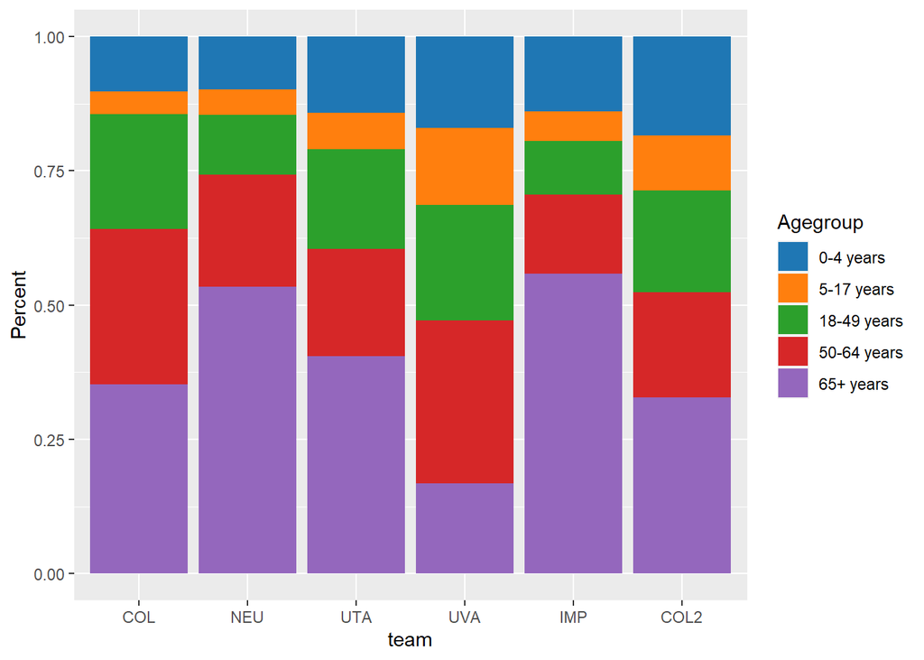

```r
#Bar chart for ages
ages <- read_ages(scn = scenario)
ggplot(ages, aes(fill=Agegroup, y=Cml, x=team)) +
  geom_bar(position="fill", stat="identity") +
  ylab("Percent")+
  scale_fill_d3()
```

```r
averted <- rbind(averted, data.frame(scenario = rep(scenario, nrow(table)),
                                     team = table$Team,
                                     reduction = table$`% Reduction in Burden (HP13)`))

averted_age <- rbind(averted_age,
                     data.frame(scenario = scenario,
                          team = ages$team[which(ages$Bin == "sm.mean")],
                          agegroup = ages$Agegroup[which(ages$Bin == "sm.mean")],
                          reduction = 100*(ages_1$Cml[which(ages_1$Bin == "sm.mean")] -
                                       ages$Cml[which(ages$Bin == "sm.mean")]) /
                            ages_1$Cml[which(ages_1$Bin == "sm.mean")]))
```

### HP23

VX2 & SC3 & AV

- “Normal”: Vaccine available 150 days after September 1
- Weekly Symptomatic Prevalence > 1% trigger, normal (VX2) vaccine availability reopening
- Antivirals

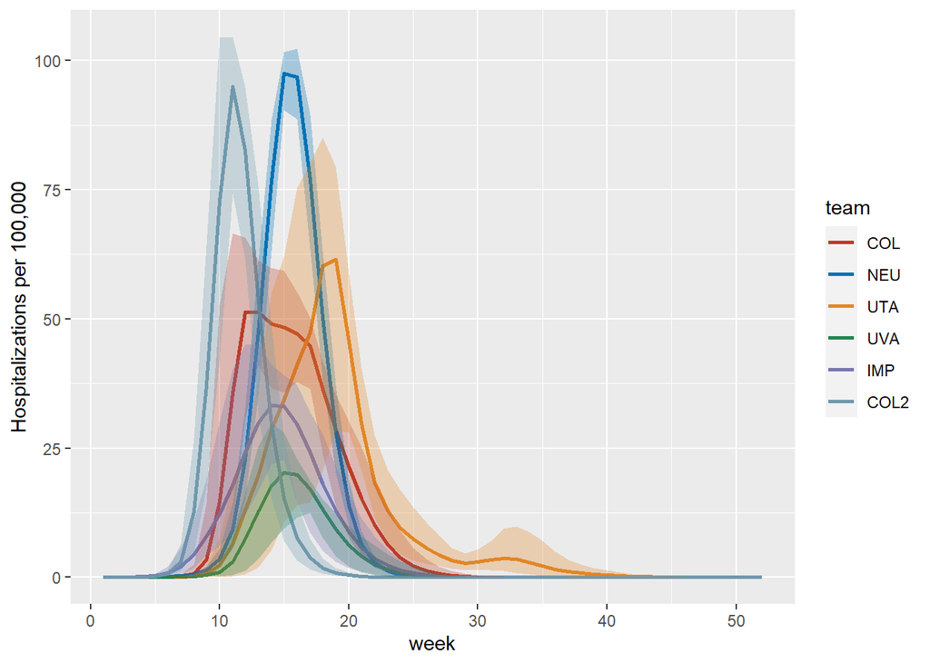

```r
scenario <- "HP23_"

long <- read_overall_mean(scn = scenario)

ggplot(data = long, aes(x = week, y = sm.mean, group = team)) +
  geom_line(aes(color = team), lwd = 1.0) +
  geom_ribbon(aes(ymin = sm.perc2p5, ymax = sm.perc97p5, fill = team), alpha = 0.3,
              show.legend = FALSE)+
  ylab("Hospitalizations per 100,000") +
  scale_color_nejm() +
  scale_fill_nejm()
```

```r
table <- cml[which(cml$Bin == "sm.mean"),]
table <- table[,-3]

table$lower <-  cml$Cml[which(cml$Bin == "sm.perc2p5")]
table$upper <-  cml$Cml[which(cml$Bin == "sm.perc97p5")]
table$Team <- table$team
table$`Cum. Hospitalizations per 100K` <- table$Cml
table$`95% CI` <- paste0("(", round(table$lower, 2), ", ", round(table$upper, 2), ")")

table$`Averted Hospitalizations per 100K (HP13)` <- ifelse(table$Team %in% table1$Team, table1$`Cum. Hospitalizations per 100K` - table$`Cum. Hospitalizations per 100K`, NA)
table$`% Reduction in Burden (HP13)` <- ifelse(table$Team %in% table1$Team, 100 * (table1$`Cum. Hospitalizations per 100K` - table$`Cum. Hospitalizations per 100K`) / table1$`Cum. Hospitalizations per 100K`, NA)

rownames(table) <- NULL

knitr::kable(table[5:9], digits = 2, caption = "HP23: Compared to HP13", align=rep('c', 4)) %>%
  kable_styling(bootstrap_options = c("striped", "hover"))
```

HP23: Compared to HP13

| Team | Cum. Hospitalizations per 100K | 95% CI | Averted Hospitalizations per 100K (HP13) | % Reduction in Burden (HP13) |
| --- | --- | --- | --- | --- |
| COL | 473.37 | (417.71, 531.94) | 28.26 | 5.63 |
| NEU | 536.75 | (535.94, 539) | 125.37 | 18.93 |
| UTA | 479.70 | (289.74, 598.04) | 354.36 | 42.49 |
| UVA | 138.82 | (107.56, 162.9) | 48.99 | 26.08 |
| IMP | 274.59 | (253.15, 299.59) | 74.27 | 21.29 |
| COL2 | 417.47 | (399.88, 437.11) | 57.35 | 12.08 |

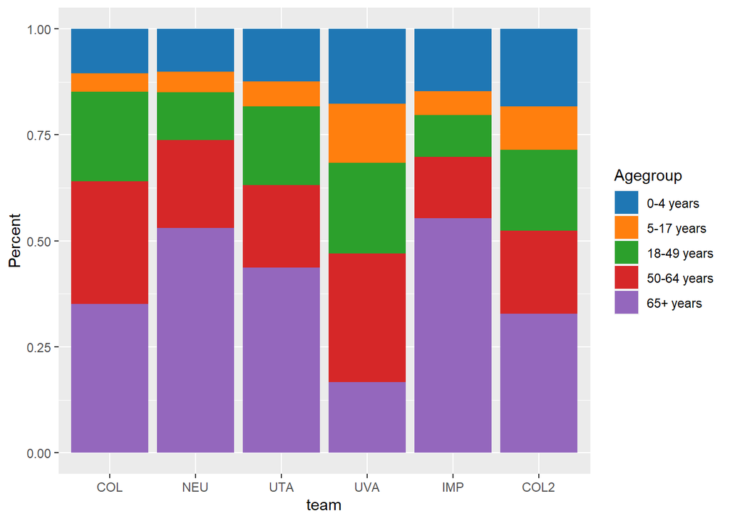

```r
#Bar chart for ages
ages <- read_ages(scn = scenario)
ggplot(ages, aes(fill=Agegroup, y=Cml, x=team)) +
  geom_bar(position="fill", stat="identity") +
  ylab("Percent")+
  scale_fill_d3()
```

```r
averted <- rbind(averted, data.frame(scenario = rep(scenario, nrow(table)),
                                     team = table$Team,
                                     reduction = table$`% Reduction in Burden (HP13)`))
averted_age <- rbind(averted_age,
                     data.frame(scenario = scenario,
                          team = ages$team[which(ages$Bin == "sm.mean")],
                          agegroup = ages$Agegroup[which(ages$Bin == "sm.mean")],
                          reduction = 100*(ages_1$Cml[which(ages_1$Bin == "sm.mean")] -
                                       ages$Cml[which(ages$Bin == "sm.mean")]) /
                            ages_1$Cml[which(ages_1$Bin == "sm.mean")]))
```

### HP24

VX2 & SC4 & AV

- “Normal”: Vaccine available 150 days after September 1
- Close on October 28, normal (VX2) vaccine availability reopening
- Antivirals

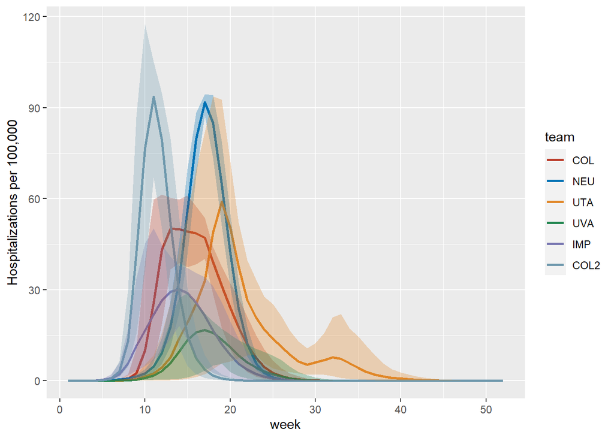

```r
scenario <- "HP24_"

long <- read_overall_mean(scn = scenario)

ggplot(data = long, aes(x = week, y = sm.mean, group = team)) +
  geom_line(aes(color = team), lwd = 1.0) +
  geom_ribbon(aes(ymin = sm.perc2p5, ymax = sm.perc97p5, fill = team), alpha = 0.3,
              show.legend = FALSE)+
  ylab("Hospitalizations per 100,000") +
  scale_color_nejm() +
  scale_fill_nejm()
```

```r
table <- cml[which(cml$Bin == "sm.mean"),]
table <- table[,-3]

table$lower <-  cml$Cml[which(cml$Bin == "sm.perc2p5")]
table$upper <-  cml$Cml[which(cml$Bin == "sm.perc97p5")]
table$Team <- table$team
table$`Cum. Hospitalizations per 100K` <- table$Cml
table$`95% CI` <- paste0("(", round(table$lower, 2), ", ", round(table$upper, 2), ")")

table$`Averted Hospitalizations per 100K (HP13)` <- ifelse(table$Team %in% table1$Team, table1$`Cum. Hospitalizations per 100K` - table$`Cum. Hospitalizations per 100K`, NA)
table$`% Reduction in Burden (HP13)` <- ifelse(table$Team %in% table1$Team, 100 * (table1$`Cum. Hospitalizations per 100K` - table$`Cum. Hospitalizations per 100K`) / table1$`Cum. Hospitalizations per 100K`, NA)

rownames(table) <- NULL

knitr::kable(table[5:9], digits = 2, caption = "HP24: Compared to HP13", align=rep('c', 4)) %>%
  kable_styling(bootstrap_options = c("striped", "hover"))
```

HP24: Compared to HP13

| Team | Cum. Hospitalizations per 100K | 95% CI | Averted Hospitalizations per 100K (HP13) | % Reduction in Burden (HP13) |
| --- | --- | --- | --- | --- |
| COL | 470.10 | (414.75, 528.41) | 31.52 | 6.28 |
| NEU | 536.38 | (535.64, 538.51) | 125.74 | 18.99 |
| UTA | 461.82 | (255.48, 602.14) | 372.24 | 44.63 |
| UVA | 136.32 | (96.87, 162.37) | 51.49 | 27.42 |
| IMP | 273.27 | (255.28, 297.41) | 75.58 | 21.67 |
| COL2 | 418.24 | (400.3, 438.36) | 56.59 | 11.92 |

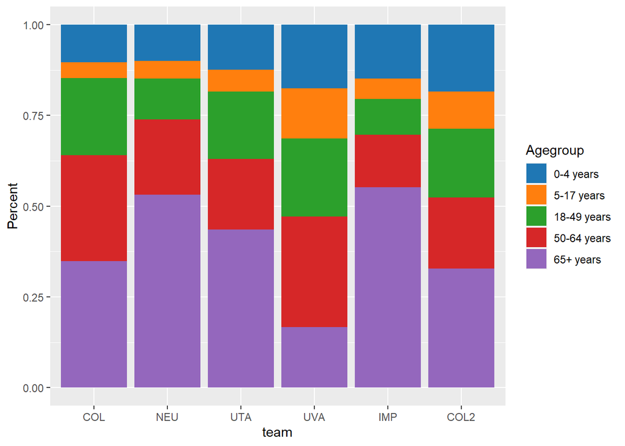

```r
#Bar chart for ages
ages <- read_ages(scn = scenario)
ggplot(ages, aes(fill=Agegroup, y=Cml, x=team)) +
  geom_bar(position="fill", stat="identity") +
  ylab("Percent")+
  scale_fill_d3()
```

```r
averted <- rbind(averted, data.frame(scenario = rep(scenario, nrow(table)),
                                     team = table$Team,
                                     reduction = table$`% Reduction in Burden (HP13)`))
averted_age <- rbind(averted_age,
                     data.frame(scenario = scenario,
                          team = ages$team[which(ages$Bin == "sm.mean")],
                          agegroup = ages$Agegroup[which(ages$Bin == "sm.mean")],
                          reduction = 100*(ages_1$Cml[which(ages_1$Bin == "sm.mean")] -
                                       ages$Cml[which(ages$Bin == "sm.mean")]) /
                            ages_1$Cml[which(ages_1$Bin == "sm.mean")]))
write.csv(averted, "Hospitalizations_EPI2.csv")
write.csv(averted_age, "Hospitalizations_age_EPI2.csv")
```